# How to estimate RPM

Paul Goldsmith-Pinkham

March 30, 2018

## Data exploration

```r
data_path <- "~/Dropbox/Basketball/data/"
gamedata <- read_csv(file.path(data_path,"2015-16/[10-20-2015]-[06-20-2016]-combined-stats.csv"),
                     col_types = cols(date = col_date(format = "%Y-%m-%d"),
                                      play_length= col_time(),
                                      game_id = col_number()))
```

First thing I need to do to study RPM is to convert this data into stint level data. I define a stint as the time that a set of players (5 away, 5 home) are on the court together between substitutions. From that definition, I want to collect:

1. the number of possessions for each team
2. the elapsed amount of time
3. the net scoring of each team
4. and the players on the team.

In the code, I construct a stint-level identifier between substitutions, and generate a measure of possesions. I follow the definition of possessions as being anytime between a team giving the ball back to the other team (so if you shoot, miss, and get the offensive rebound, that doesn’t count as a new possession. This seemed to be how things are defined, but that doesn’t seem logical to me. ) I then calculate the amount of scoring by the home and away team, as well as the number of minutes and posession per stint.

```r
per_stint <- gamedata %>%  arrange(game_id, period, desc(remaining_time)) %>%
                mutate(end_stint = type == "sub" | play_id == 0) %>%
                filter((lag(end_stint) == 0 & end_stint == 0) |
                      (end_stint == 1 & lead(end_stint) == 0))  %>%
                mutate(new_possession = team != lag(team)) %>%
                mutate(stint_id =cumsum(end_stint)) %>%
                select(stint_id, starts_with("a"), starts_with("h"), play_length, period, new_possession,
                      remaining_time, team, game_id, -assist, -away, -home, event_type)


per_stint_stats <- per_stint %>%
                    group_by(game_id, stint_id) %>%
                    summarize(net_home_score = last(home_score) - first(home_score),
                              net_away_score = last(away_score) - first(away_score),
                              minutes_played = sum(play_length, na.rm=TRUE),
                              num_possessions = sum(new_possession, na.rm=TRUE))
```

When I do some spot checks of the data, I find one outlier:

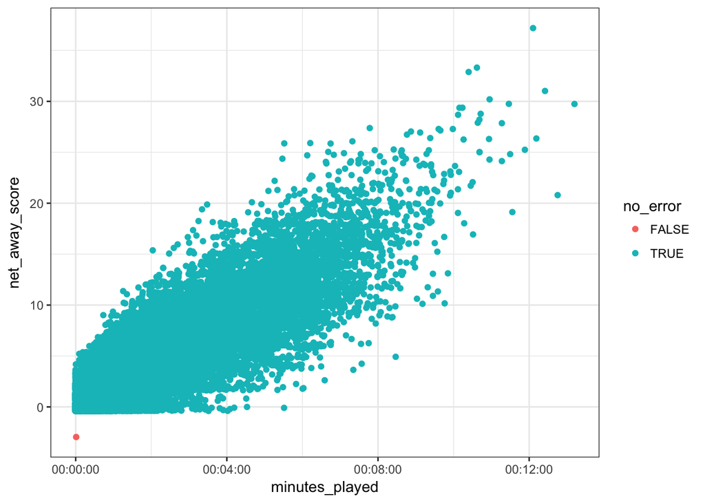

That one game appears to be a data screwup in the last row, assuming there was an overtime when there actually wasn’t:

```r
filter(per_stint_stats, net_away_score < 0)
```

```
## # A tibble: 1 x 6
## # Groups:   game_id [1]
##     game_id stint_id net_home_score net_away_score minutes_played
##       <dbl>    <int>          <int>          <int> <time>
## 1 21500916.    25884             -2             -3 00:00:01
## # ... with 1 more variable: num_possessions <int>
```

```r
filter(per_stint, stint_id == 25884) %>% select(remaining_time, game_id, period, event_type, home_score, away_score)
```

```
## # A tibble: 9 x 6
##   remaining_time   game_id period event_type      home_score away_score
##   <time>             <dbl>  <int> <chr>                <int>      <int>
## 1 00:00:02       21500916.      4 sub                    116        115
## 2 00:00:00       21500916.      4 foul                   116        115
## 3 00:00:00       21500916.      4 free throw             117        115
## 4 00:00:00       21500916.      4 free throw             117        115
## 5 00:00:00       21500916.      4 rebound                117        115
## 6 00:00:00       21500916.      4 miss                   117        115
## 7 00:00:00       21500916.      4 rebound                117        115
## 8 00:00:00       21500916.      4 end of period          117        115
## 9 00:05:00       21500916.      5 start of period        114        112
```

For the sake of simplicity, I just drop that stint:

```r
per_stint_stats <- filter(per_stint_stats, net_home_score >= 0)
filter(per_stint_stats, net_away_score < 0)
```

```
## # A tibble: 0 x 6
## # Groups:   game_id [0]
## # ... with 6 variables: game_id <dbl>, stint_id <int>,
## #   net_home_score <int>, net_away_score <int>, minutes_played <time>,
## #   num_possessions <int>
```

```r
per_stint_stats <- per_stint %>%
                    group_by(game_id, stint_id) %>%
                    summarize(net_home_score = last(home_score) - first(home_score), net_away_score = last(away_score) - first(away_score),
                              minutes_played = sum(play_length, na.rm=TRUE), num_possessions = sum(new_possession, na.rm=TRUE)) %>%
                    filter(net_home_score >= 0) %>% filter(num_possessions != 0)
per_stint_stats <- per_stint %>% select(a1:a5, h1:h5, stint_id, game_id) %>% group_by(stint_id, game_id) %>% filter(row_number()==1) %>%
                    gather(key = "player", value = "playername", -stint_id, -game_id)   %>%
                    group_by(stint_id, game_id) %>%
                    right_join(per_stint_stats)
```

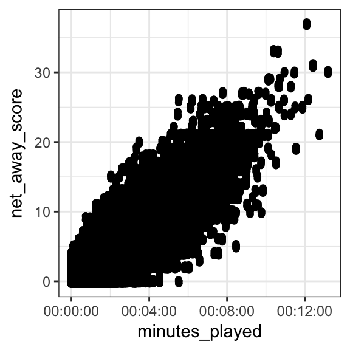

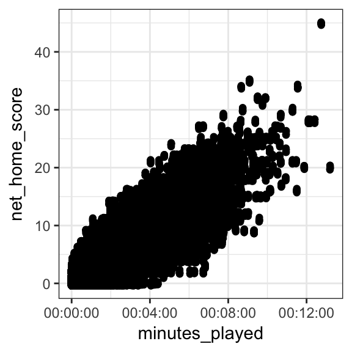

```r
scores1 <- ggplot(data = per_stint_stats) +
  geom_jitter(aes(x = minutes_played, y = net_away_score)) + theme_bw()
scores2 <- ggplot(data = per_stint_stats) +
  geom_jitter(aes(x = minutes_played, y = net_home_score)) + theme_bw()
plot(scores1)
plot(scores2)
```

## Plus-Minus

Now, with this data, I need to construct a matrix of player names, which has the net score per stint, the number of posessions, and then a column for every player in the league. It’s a little ridiculous, but with this design matrix (with a negative stint value for the away players), and a negative 1 or positive 1, depending on the player being home or away, I can estimate the Player effects using ridge regression. I can then construct the matrix and run ridge regression. The trick with ridge regression is that you need to cross-validate a penalty parameter, so I do that, then pick the optimal lambda and use the coefficients from that.

```r
stint_matrix <- per_stint_stats %>% ungroup() %>%
                  mutate(home = (-1 + 2*(str_detect(player, "h")))) %>% mutate(plus_minus = (net_home_score-net_away_score)/ num_possessions) %>%
                  select(plus_minus, playername, stint_id, home)

matrix <- stint_matrix %>% mutate(i = row_number()) %>% group_by(stint_id) %>% spread(key = playername, value=home, fill=0)
x <- matrix %>% ungroup() %>% select(-plus_minus, -stint_id, -i) %>% data.matrix()
y <- matrix %>% ungroup() %>% select(plus_minus) %>% data.matrix()
weights <- per_stint_stats %>% ungroup() %>% select(num_possessions) %>% data.matrix()
lambdas <- 10^seq(3, -2, by = -.1)

cv_fit <- cv.glmnet(x, y, alpha = 0, lambda = lambdas, weight=weights)
opt_lambda <- cv_fit$lambda.min
fit <- cv_fit$glmnet.fit
glm_betas <- tidy(fit) %>%
  filter(term != "(Intercept)", lambda == opt_lambda) %>%
    select(player = term, coef = estimate) %>% mutate(APM = coef*100) %>%
  arrange(APM)
```

This gives a measure of why I called APMs – Adjusted Plus Minus – which are regularized. So, how good are these? I can spot check the top, i.e. “sniff test”:

```r
glm_betas %>% arrange(desc(APM)) %>% filter(row_number() < 25)
```

```
##                    player       coef       APM
## 1          Jarnell Stokes 0.10937669 10.937669
## 2           Keith Appling 0.09233417  9.233417
## 3             Matt Bonner 0.07058533  7.058533
## 4  Michael Kidd-Gilchrist 0.05764276  5.764276
## 5            KJ McDaniels 0.04696972  4.696972
## 6              Tim Duncan 0.04691939  4.691939
## 7           Stephen Curry 0.04643340  4.643340
## 8           Manu Ginobili 0.04497161  4.497161
## 9          Draymond Green 0.04325508  4.325508
## 10          Kawhi Leonard 0.04288838  4.288838
## 11            Danny Green 0.04242924  4.242924
## 12            Patty Mills 0.04158193  4.158193
## 13           Festus Ezeli 0.04037663  4.037663
## 14           Andrew Bogut 0.04021776  4.021776
## 15          Klay Thompson 0.03904427  3.904427
## 16             David West 0.03825046  3.825046
## 17           Jordan Adams 0.03658291  3.658291
## 18        Harrison Barnes 0.03639887  3.639887
## 19             Chris Paul 0.03549678  3.549678
## 20      LaMarcus Aldridge 0.03488998  3.488998
## 21              CJ Wilcox 0.03469467  3.469467
## 22           LeBron James 0.03467366  3.467366
## 23         Andre Iguodala 0.03420702  3.420702
## 24      Russell Westbrook 0.03381551  3.381551
```

So some of these make sense – Steph Curry, Tim Duncan (remember, this is 2015-2016), Draymond Green… but who the fork is Jarnell Stokes? Well, he’s a dude who played two games. Perhaps unsurprisingly, Keith Appling also played 1 game (it’s actually kind of sad, he was in jail for a year after this). So perhaps an easy check is to limit it to those players who ESPN thinks are real players. I merge my values to ESPN’s RPM values for 2015-16:

```r
espn_rpm_2015 <- read_csv("~/repos/rpm/espn_rpm_2015.csv")
espn_rpm <- espn_rpm_2015 %>% separate(NAME, c("player", "pos"), sep=",") %>%
            left_join(glm_betas) %>%
            arrange(desc(APM))
cor(espn_rpm %>% filter(GP > 0) %>% select(RPM, APM), use="na.or.complete")
```

```
##           RPM       APM
## RPM 1.0000000 0.4649971
## APM 0.4649971 1.0000000
```

```r
cor(espn_rpm %>% filter(GP > 40) %>% select(RPM, APM), use="na.or.complete")
```

```
##           RPM       APM
## RPM 1.0000000 0.6574186
## APM 0.6574186 1.0000000
```

With players with 40+ games, the correlation between RPM and APM is pretty good – around 66 percent! What’s it look like plotted?

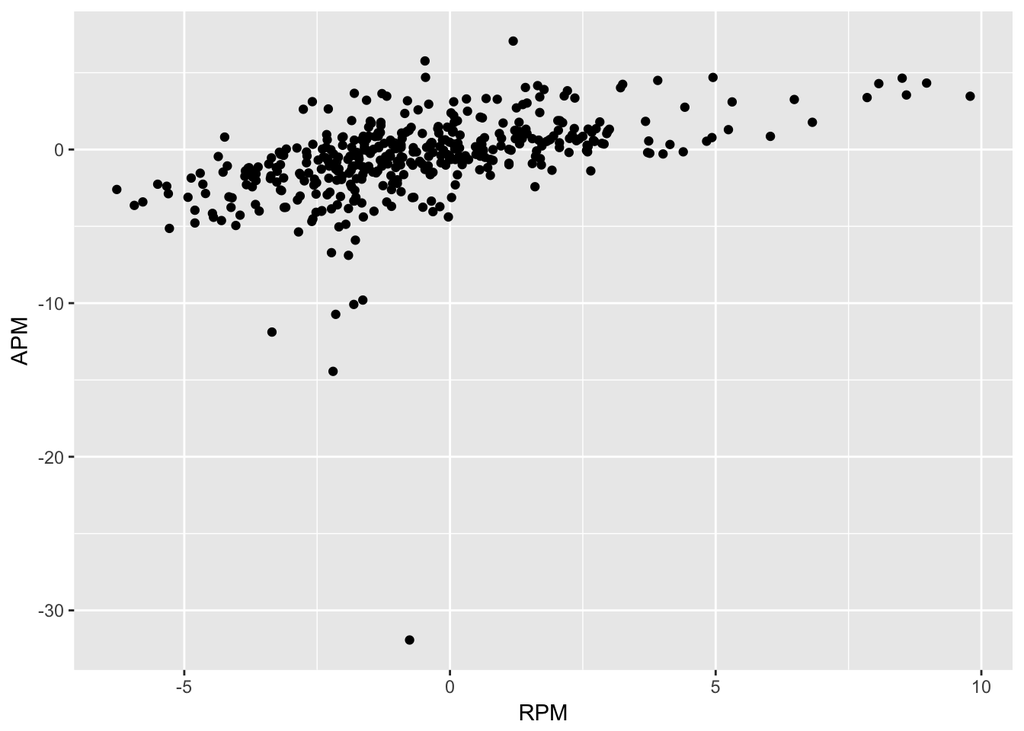

If we focus on players with 40+ games?

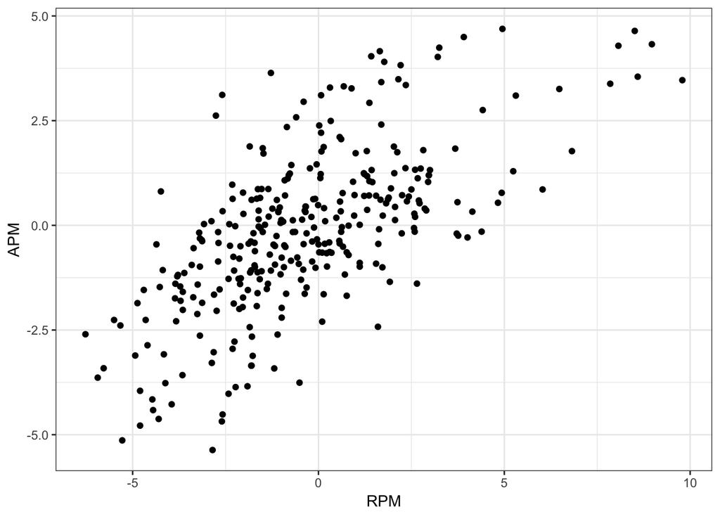

The new top 25 list:

```r
top25 <- espn_rpm%>% filter(GP > 40, MPG > 10) %>% arrange(desc(APM)) %>% filter(row_number() < 25) %>% select(RK, player, pos, GP, MPG, TEAM, APM, RPM, DRPM, ORPM, WINS  )
knitr::kable(
  top25,
  caption = "Top 25, APM method (with ESPN Rank + RPM)"
)
```

Top 25, APM method (with ESPN Rank + RPM)

| RK | player | pos | GP | MPG | TEAM | APM | RPM | DRPM | ORPM | WINS |
| --- | --- | --- | --- | --- | --- | --- | --- | --- | --- | --- |
| 12 | Tim Duncan | C | 61 | 25.2 | SA | 4.691939 | 4.95 | 5.43 | -0.48 | 7.69 |
| 4 | Stephen Curry | PG | 79 | 34.2 | GS | 4.643340 | 8.51 | 0.86 | 7.65 | 21.10 |
| 19 | Manu Ginobili | SG | 58 | 19.6 | SA | 4.497161 | 3.91 | 1.91 | 2.00 | 5.12 |
| 2 | Draymond Green | PF | 81 | 34.7 | GS | 4.325508 | 8.97 | 5.04 | 3.93 | 22.66 |
| 5 | Kawhi Leonard | SF | 72 | 33.1 | SA | 4.288838 | 8.07 | 3.88 | 4.19 | 16.74 |
| 24 | Danny Green | SG | 79 | 26.1 | SA | 4.242924 | 3.25 | 2.93 | 0.32 | 8.18 |
| 72 | Patty Mills | PG | 81 | 20.5 | SA | 4.158193 | 1.65 | -0.36 | 2.01 | 5.05 |
| 82 | Festus Ezeli | C | 46 | 16.7 | GS | 4.037663 | 1.42 | 2.19 | -0.77 | 2.31 |
| 25 | Andrew Bogut | C | 70 | 20.7 | GS | 4.021776 | 3.21 | 5.45 | -2.24 | 6.03 |
| 65 | Klay Thompson | SG | 80 | 33.3 | GS | 3.904427 | 1.77 | -0.61 | 2.38 | 8.70 |
| 52 | David West | PF | 78 | 18.0 | SA | 3.825046 | 2.21 | 2.90 | -0.69 | 4.67 |
| 236 | Harrison Barnes | SF | 66 | 30.9 | GS | 3.639887 | -1.28 | -1.11 | -0.17 | 2.47 |
| 3 | Chris Paul | PG | 74 | 32.7 | LAC | 3.549678 | 8.59 | 2.44 | 6.15 | 18.12 |
| 53 | LaMarcus Aldridge | PF | 74 | 30.6 | SA | 3.488998 | 2.15 | 1.49 | 0.66 | 7.46 |
| 1 | LeBron James | SF | 76 | 35.6 | CLE | 3.467366 | 9.79 | 3.30 | 6.49 | 21.55 |
| 70 | Andre Iguodala | SF | 65 | 26.6 | GS | 3.420702 | 1.69 | 0.61 | 1.08 | 5.44 |
| 6 | Russell Westbrook | PG | 80 | 34.4 | OKC | 3.381551 | 7.85 | 0.60 | 7.25 | 19.53 |
| 47 | Steven Adams | C | 80 | 25.2 | OKC | 3.350651 | 2.35 | 2.77 | -0.42 | 7.05 |
| 109 | Matthew Dellavedova | PG | 76 | 24.6 | CLE | 3.319381 | 0.68 | -0.71 | 1.39 | 4.36 |
| 125 | JJ Redick | SG | 75 | 28.0 | LAC | 3.290591 | 0.31 | -1.59 | 1.90 | 4.59 |
| 103 | Serge Ibaka | PF | 78 | 32.1 | OKC | 3.270348 | 0.89 | 0.86 | 0.03 | 6.48 |
| 8 | Kevin Durant | SF | 72 | 35.8 | OKC | 3.256171 | 6.48 | 0.97 | 5.51 | 16.00 |
| 346 | Anthony Morrow | SG | 68 | 13.6 | OKC | 3.115166 | -2.59 | -3.05 | 0.46 | 0.32 |
| 140 | Boris Diaw | C | 76 | 18.2 | SA | 3.107264 | 0.07 | 0.64 | -0.57 | 2.83 |